# Canonical Analysis

**Canonical Analysis** References : https://stats.idre.ucla.edu/r/dae/canonical-correlation-analysis/

**Examples of canonical correlation analysis**

**Example 1.** A researcher has collected data on three psychological variables, four academic variables (standardized test scores) and gender for 600 college freshman. She is interested in how the set of psychological variables relates to the academic variables and gender. In particular, the researcher is interested in how many dimensions (canonical variables) are necessary to understand the association between the two sets of variables.

**Example 2.** A researcher is interested in exploring associations among factors from two multidimensional personality tests, the MMPI and the NEO. She is interested in what dimensions are common between the tests and how much variance is shared between them. She is specifically interested in finding whether the neuroticism dimension from the NEO can account for a substantial amount of shared variance between the two tests.

**Load Library**

```r
library(ggplot2)
library(CCA)
library(vegan)
library(CCP)
```

**Description of the data** For our analysis example, we are going to expand example 1 about investigating the associations between psychological measures and academic achievement measures.We have a data file, mmreg.dta, with 600 observations on eight variables.

The psychological variables are

- locus_of_control
- self_concept
- motivation

The academic variables are

- standardized tests in reading (read)
- writing (write)
- math (math)
- science (science)

the variable female is a zero-one indicator variable with the one indicating a female student.

```r
mm <- read.csv("https://stats.idre.ucla.edu/stat/data/mmreg.csv")
colnames(mm) <- c("Control", "Concept", "Motivation", "Read", "Write", "Math",
                  "Science", "Sex")
summary(mm)
```

```
    Control            Concept            Motivation          Read          Write
 Min.   :-2.23000   Min.   :-2.620000   Min.   :0.0000   Min.   :28.3   Min.   :25.50
 1st Qu.:-0.37250   1st Qu.:-0.300000   1st Qu.:0.3300   1st Qu.:44.2   1st Qu.:44.30
 Median : 0.21000   Median : 0.030000   Median :0.6700   Median :52.1   Median :54.10
 Mean   : 0.09653   Mean   : 0.004917   Mean   :0.6608   Mean   :51.9   Mean   :52.38
 3rd Qu.: 0.51000   3rd Qu.: 0.440000   3rd Qu.:1.0000   3rd Qu.:60.1   3rd Qu.:59.90
 Max.   : 1.36000   Max.   : 1.190000   Max.   :1.0000   Max.   :76.0   Max.   :67.10
      Math          Science           Sex
 Min.   :31.80   Min.   :26.00   Min.   :0.000
 1st Qu.:44.50   1st Qu.:44.40   1st Qu.:0.000
 Median :51.30   Median :52.60   Median :1.000
 Mean   :51.85   Mean   :51.76   Mean   :0.545
 3rd Qu.:58.38   3rd Qu.:58.65   3rd Qu.:1.000
 Max.   :75.50   Max.   :74.20   Max.   :1.000
```

```r
# Tabulasi data
xtabs(~Sex, data = mm)
```

```
Sex
  0   1
273 327
```

**Splitting, Grouping Data**

```r
psych <- mm[, 1:3] #Variabel di kolom 1-3 dikelompokan menjadi satu data
acad <- mm[, 4:8] #Variabel di kolom 4-8 dikelompokan menjadi satu data

X <- psych
Y <- acad
```

**Correlation Structure** Struktur korelasi antara variabel X(psikologis) dan variabel Y(academic). Ditampilkan dalam 2 bentuk, grafik berwarna dan angka

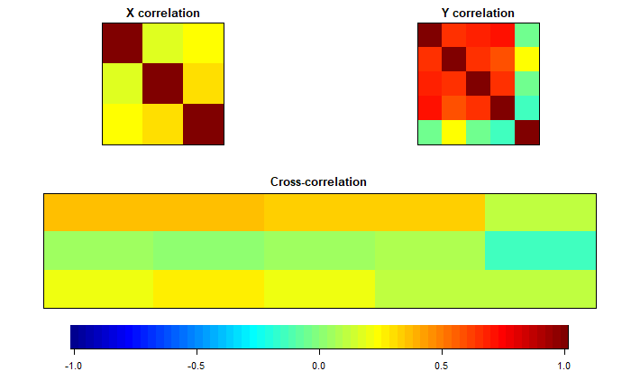

```r
correl <- matcor(X, Y) #Fungsi untuk menampilkan korelasi antar variabel
img.matcor(correl, type = 2) #bentuk korelasi yang ditampilkan. Gambar tipe 2
```

```r
matcor(X, Y) #korelasi antar variabel dengan bentuk angka
```

```
$Xcor
             Control   Concept Motivation
Control    1.0000000 0.1711878  0.2451323
Concept    0.1711878 1.0000000  0.2885707
Motivation 0.2451323 0.2885707  1.0000000

$Ycor
               Read     Write       Math    Science         Sex
Read     1.00000000 0.6285909  0.6792757  0.6906929 -0.04174278
Write    0.62859089 1.0000000  0.6326664  0.5691498  0.24433183
Math     0.67927568 0.6326664  1.0000000  0.6495261 -0.04821830
Science  0.69069291 0.5691498  0.6495261  1.0000000 -0.13818587
Sex     -0.04174278 0.2443318 -0.0482183 -0.1381859  1.00000000

$XYcor
             Control     Concept Motivation        Read      Write       Math     Science
Control    1.0000000  0.17118778 0.24513227  0.37356505 0.35887684  0.3372690  0.32462694
Concept    0.1711878  1.00000000 0.28857075  0.06065584 0.01944856  0.0535977  0.06982633
Motivation 0.2451323  0.28857075 1.00000000  0.21060992 0.25424818  0.1950135  0.11566948
Read       0.3735650  0.06065584 0.21060992  1.00000000 0.62859089  0.6792757  0.69069291
Write      0.3588768  0.01944856 0.25424818  0.62859089 1.00000000  0.6326664  0.56914983
Math       0.3372690  0.05359770 0.19501347  0.67927568 0.63266640  1.0000000  0.64952612
Science    0.3246269  0.06982633 0.11566948  0.69069291 0.56914983  0.6495261  1.00000000
Sex        0.1134108 -0.12595132 0.09810277 -0.04174278 0.24433183 -0.0482183 -0.13818587
                   Sex
Control     0.11341075
Concept    -0.12595132
Motivation  0.09810277
Read       -0.04174278
Write       0.24433183
Math       -0.04821830
Science    -0.13818587
Sex         1.00000000
```

```r
# Korelasi kanonik
cc1 <- cc(X, Y)      # function for the R package 'CCA'
cc1$cor
```

```
[1] 0.4640861 0.1675092 0.1039911
```

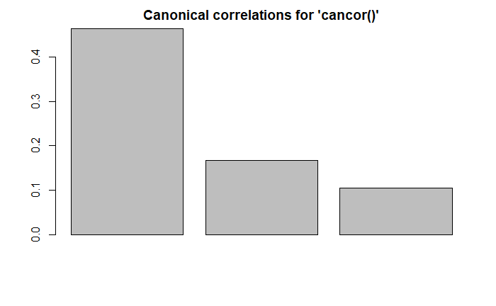

```r
barplot(cc1$cor, main = "Canonical correlations for 'cancor()'", col = "gray")
```

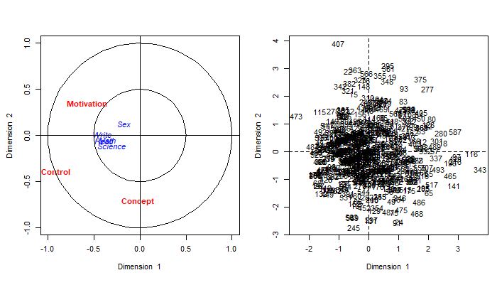

```r
plt.cc(cc1, var.label = TRUE)
```

```r
# raw canonical coefficients
cc1[3:4]
```

```
$xcoef
                 [,1]       [,2]       [,3]
Control    -1.2538339 -0.6214776 -0.6616896
Concept     0.3513499 -1.1876866  0.8267210
Motivation -1.2624204  2.0272641  2.0002283

$ycoef
                [,1]         [,2]         [,3]
Read    -0.044620600 -0.004910024  0.021380576
Write   -0.035877112  0.042071478  0.091307329
Math    -0.023417185  0.004229478  0.009398182
Science -0.005025152 -0.085162184 -0.109835014
Sex     -0.632119234  1.084642326 -1.794647036
```

The raw canonical coefficients are interpreted in a manner analogous to interpreting regression coefficients i.e., for the variable read, a one unit increase in reading leads to a **.0446** decrease in the first canonical variate of set 2 when all of the other variables are held constant. Here is another example: being female leads to a **.6321** decrease in the dimension 1 for the academic set with the other predictors held constant.

```r
# tests of canonical dimensions
rho <- cc1$cor
## Define number of observations, number of variables in first set, and number of variables in the second set.
n <- dim(psych)[1]
p <- length(psych)
q <- length(acad)

## Calculate p-values using the F-approximations of different test statistics:
p.asym(rho, n, p, q, tstat = "Wilks")
```

```
Wilks' Lambda, using F-approximation (Rao's F):
              stat    approx df1      df2     p.value
1 to 3:  0.7543611 11.715733  15 1634.653 0.000000000
2 to 3:  0.9614300  2.944459   8 1186.000 0.002905057
3 to 3:  0.9891858  2.164612   3  594.000 0.091092180
```

```r
p.asym(rho, n, p, q, tstat = "Hotelling")
```

```
 Hotelling-Lawley Trace, using F-approximation:
               stat    approx df1  df2     p.value
1 to 3:  0.31429738 12.376333  15 1772 0.000000000
2 to 3:  0.03980175  2.948647   8 1778 0.002806614
3 to 3:  0.01093238  2.167041   3 1784 0.090013176
```

As shown in the table above, the first test of the canonical dimensions tests whether all three dimensions are significant (they are, F = 11.72), the next test tests whether dimensions 2 and 3 combined are significant (they are, F = 2.94). Finally, the last test tests whether dimension 3, by itself, is significant (it is not). Therefore dimensions 1 and 2 must each be significant while dimension three is not.

When the variables in the model have very different standard deviations, the standardized coefficients allow for easier comparisons among the variables. Next, we’ll compute the standardized canonical coefficients.

```r
# standardized psych canonical coefficients diagonal matrix of psych sd's
s1 <- diag(sqrt(diag(cov(psych))))
s1 %*% cc1$xcoef
```

```
           [,1]       [,2]       [,3]
[1,] -0.8404196 -0.4165639 -0.4435172
[2,]  0.2478818 -0.8379278  0.5832620
[3,] -0.4326685  0.6948029  0.6855370
```

```r
s2 <- diag(sqrt(diag(cov(acad))))
s2 %*% cc1$ycoef
```

```
            [,1]        [,2]        [,3]
[1,] -0.45080116 -0.04960589  0.21600760
[2,] -0.34895712  0.40920634  0.88809662
[3,] -0.22046662  0.03981942  0.08848141
[4,] -0.04877502 -0.82659938 -1.06607828
[5,] -0.31503962  0.54057096 -0.89442764
```

**Sample Write-Up of the Analysis**

There is a lot of variation in the write-ups of canonical correlation analyses. The write-up below is fairly minimal, including only the tests of dimensionality and the standardized coefficients.

Table 1: Tests of Canonical Dimensions

```
        Canonical  Mult.
```

Dimension | Corr. | F | df1 | df2 | p

```
1         0.46     11.72   15   1634.7  0.0000
2         0.17      2.94    8   1186    0.0029
3         0.10      2.16    3    594    0.0911
```

Table 2: Standardized Canonical Coefficients

```
                        Dimension
                       1         2
```

Psychological Variables

```
locus of control    -0.84     -0.42
self-concept         0.25     -0.84
motivation          -0.43      0.69
```

Academic Variables plus Gender

```
reading             -0.45     -0.05
writing             -0.35      0.41
math                -0.22      0.04
science             -0.05     -0.83
gender (female=1)   -0.32      0.54
```

Tests of dimensionality for the canonical correlation analysis, as shown in Table 1, indicate that two of the three canonical dimensions are statistically significant at the .05 level. Dimension 1 had a canonical correlation of 0.46 between the sets of variables, while for dimension 2 the canonical correlation was much lower at 0.17.

Table 2 presents the standardized canonical coefficients for the first two dimensions across both sets of variables. For the psychological variables, the first canonical dimension is most strongly influenced by locus of control (-.84) and for the second dimension self-concept (-.84) and motivation (.69). For the academic variables plus gender, the first dimension was comprised of reading (-.45), writing (-.35) and gender (-.32). For the second dimension writing (.41), science (-.83) and gender (.54) were the dominating variables.